# Tutorial on Bayesian Graphical Modeling

## Fit the Model

Before we fit the model, it’s useful to explore the function we’ll use:

```r
?easybgm
```

Here’s the full function signature to get oriented:

```r
easybgm(
  data,
  type,
  package = NULL,
  not_cont = NULL,
  iter = 10000,
  save = FALSE,
  centrality = FALSE,
  progress = TRUE,
  posterior_method = "model-averaged",
  ...
)
```

The `type` argument tells easybgm what kind of data you’re working with — for example, `"continuous"`, `"binary"`, `"ordinal"`, or `"mixed"`. The package argument chooses the estimation engine.

To keep things fast and simple for this example, we’ll treat the data as if it were continuous (yes, even though it isn’t fully), and use `BGGM` to fit the model.

```r
set.seed(1)
fit = easybgm(
  data = data,
  type = "continuous",
  package = "BGGM",
  iter = 1e5,
  burnin = 1e4,
  save = TRUE,
  centrality = TRUE,
  progress = FALSE)
```

Now let’s fit the model and summarize the results.

**Exercise**

Fill in the blanks below to use the `easybgm()` function on the workshop dataset and inspect the `summary(fit)` output.

```r
set.seed(1)
fit = easybgm(data = data,
              type = ____________,
              package = ____________,
              iter = 1e5,
              burnin = 1e4,
              save = TRUE,
              centrality = TRUE,
              progress = TRUE)
summary(fit)
```

✅ What is the total number of edges?  
✅ Which edge(s) are excluded with high certainty?

**Solution (R)**

```r
set.seed(1)
fit = easybgm(data = data,
              type = "continuous",
              package = "BGGM",
              iter = 1e5,
              burnin = 1e4,
              save = TRUE,
              centrality = TRUE,
              progress = TRUE)
summary(fit)
```

```r
 BAYESIAN ANALYSIS OF NETWORKS
 Model type: ggm
 Number of nodes: 13
 Fitting Package: bggm
---
 EDGE SPECIFIC OVERVIEW
                  Relation Estimate Posterior Incl. Prob.  Inclusion BF     Category
         stress-depression    0.593                 1.000 1.513714e+196     included
        anxiety-depression    0.357                 1.000  5.701982e+58     included
    extraverted-depression   -0.023                 0.119  1.350000e-01 inconclusive
    quarrelsome-depression    0.156                 1.000  3.565962e+09     included
     dependable-depression    0.038                 0.246  3.260000e-01 inconclusive
               ...             ...                    ...         ...         ...

 Bayes Factors larger than 10 were considered sufficient evidence for the classification
 Bayes factors were obtained using Bayesian model-averaging.
 ---
 AGGREGATED EDGE OVERVIEW
 Number of edges with sufficient evidence for inclusion: 47
 Number of edges with insufficient evidence: 11
 Number of edges with sufficient evidence for exclusion: 20
 Number of possible edges: 78
```

**Solution (JASP)**

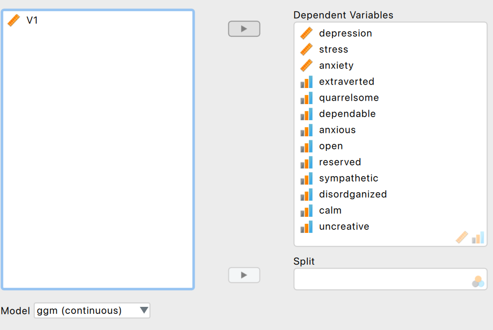

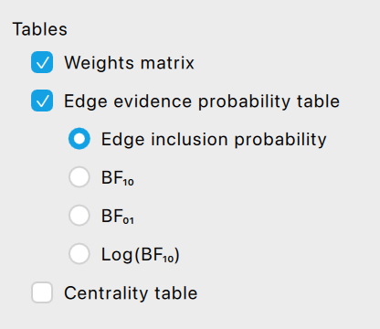

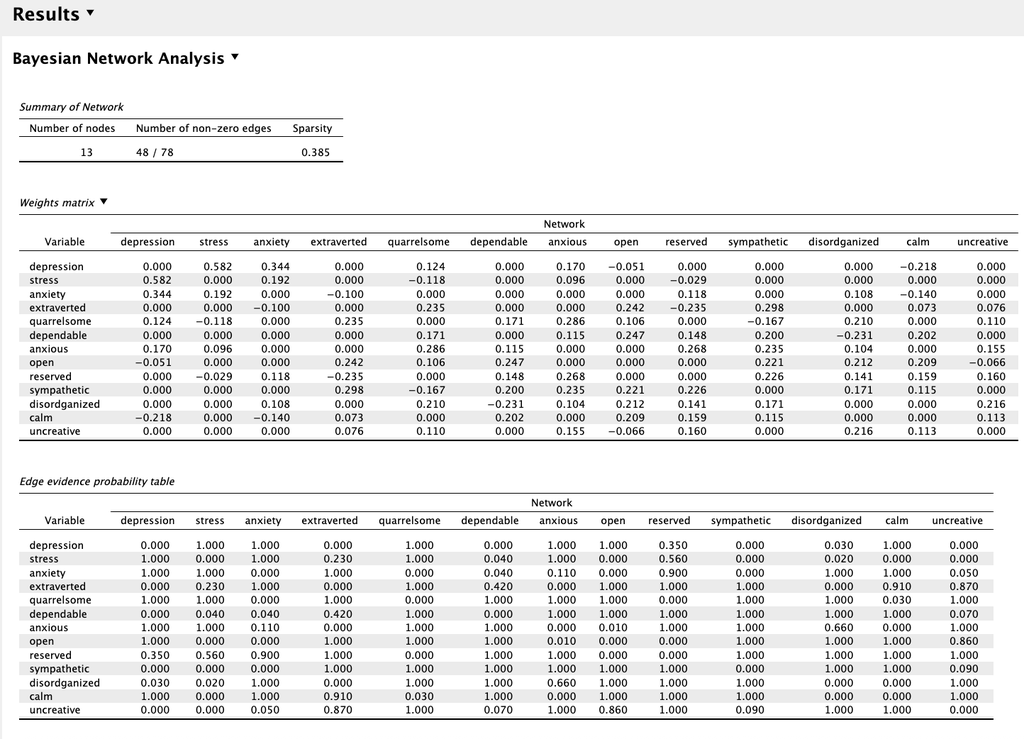